# Analysis of fire burn severity and post-fire vegetation recovery with Landsat time-series

GEM520 Lab 8 - Final Demonstration of R skills

Pritty Arattu

05 December 2025

# Introduction

Summer 2017 was considered as one the worst wild fire season in BC (until 2023), with over 1.2 million ha of burned areas, 65,000 people displaced and $649 million spent on fire suppression (https://www2.gov.bc.ca/gov/content/safety/wildfire-status/about-bcws/wildfire-history/wildfire-season-summary).

The Prouton Lakes fire (fire ID C30870) burned part of the Alex Fraser Research Forest (AFRF) located near Williams Lake, BC, on the traditional, ancestral and unceded territory of the T’exelcemc, Xatsu’ll and Esket First Nations. The burn severity varied from low-severity ground fire to high-severity canopy fire.

### Lab objective

The objective of this lab is to quantify the burn severity of the Prouton Lakes fire and examine the recovery and re-establishment of vegetation in the years following the fire. You will use a Landsat 8 OLI time-series of images acquired between the 1<sup>st</sup> of July and the 31<sup>st</sup> of August between 2013 and 2021.

### Description of data

#### Landsat time-series

Landsat 8 Collection 2 Level-2 surface reflectance (SR) products are generated using the Land Surface Reflectance Code (LaSRC) algorithm that corrects for atmospheric effects at the time of the image acquisition. Unlike Level-1 products that represent top-of-atmosphere reflectance, Level-2 SR products therefore represent the fraction of incoming sunlight reflected by the Earth’s surface (bottom-of-atmosphere) and can be combined and compared across time and space. Land surface temperature (ST) products are also generated in Landsat 8 Level-2 products. The surface reflectance and surface temperature products are accompanied by pixel-level quality assessment (QA) layers that indicate the presence of clouds, cloud shadows, snow/ice and water.

We focused on a single Landsat scene overlapping the study area (WRS Path 048; WRS Row 023) and downloaded all the Level-2 products acquired between the 1<sup>st</sup> of July and the 31<sup>st</sup> of August between 2013 and 2021 from the [USGS Earth Explorer](https://earthexplorer.usgs.gov/). This resulted in 35 products of approximately 1 GB each. Each product is named as described below.

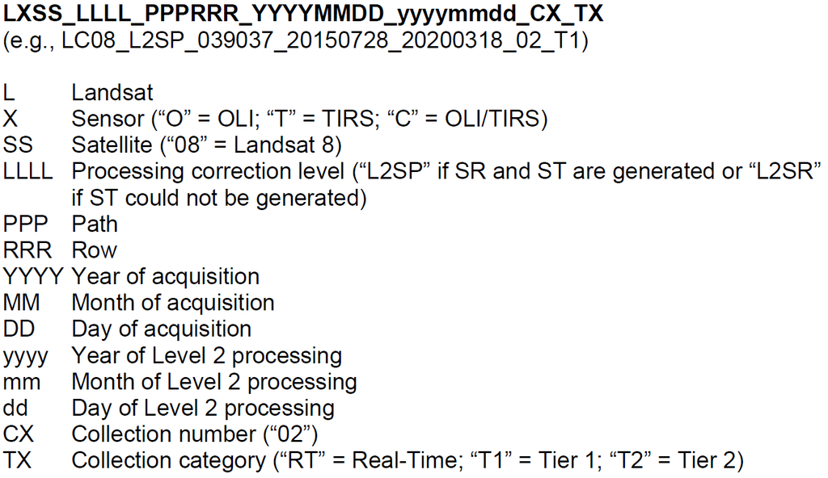

Each product contains 19 TIF files (SR, ST and QA layers) and a Metadata file.

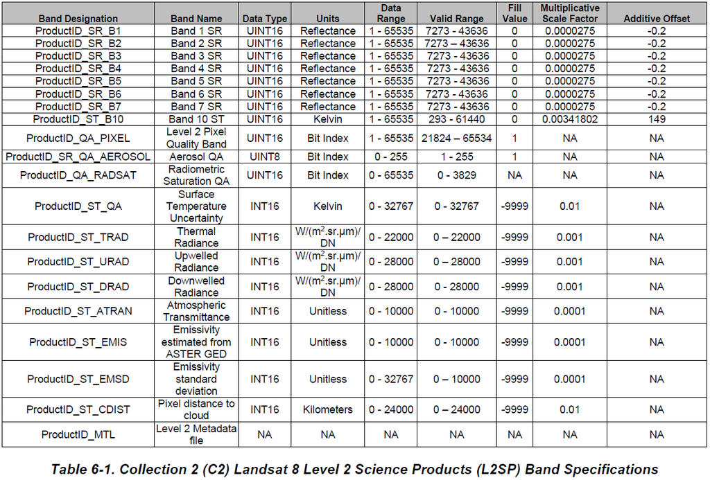

The surface reflectance measured in the spectral bands of the OLI sensor are labeled as SR_B# where # is the band number

| Band Number | Band Name | Wavelength (um) | Spatial resolution (m) |
| --- | --- | --- | --- |
| 1 | Band 1 - Coastal aerosol | 0.43-0.45 | 30 |
| 2 | Band 2 - Blue | 0.45-0.51 | 30 |
| 3 | Band 3 - Green | 0.53-0.59 | 30 |
| 4 | Band 4 - Red | 0.64-0.67 | 30 |
| 5 | Band 5 - Near Infrared (NIR) | 0.85-0.88 | 30 |
| 6 | Band 6 - SWIR 1 | 1.57-1.65 | 30 |
| 7 | Band 7 - SWIR 2 | 2.11-2.29 | 30 |

The `QA_PIXEL` layer indicates the presence of clouds, cirrus, snow/ice and water as well as confidence levels in the presence of each. A 16-digit binary number is used to encode each condition.

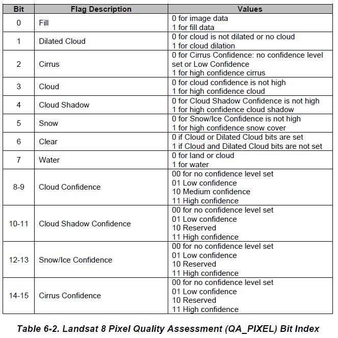

We show below how pixel values are determined for 4 conditions: clear, water, high confidence cloud and high confidence cloud shadow. Additional examples are provided in the Table 6-3 of the [Landsat 8 Collection 2 Level-2 Science Product Guide](https://prd-wret.s3.us-west-2.amazonaws.com/assets/palladium/production/atoms/files/LSDS-1619_Landsat-8-Collection2_Level-2_Science-Product-Guide-v3.pdf)

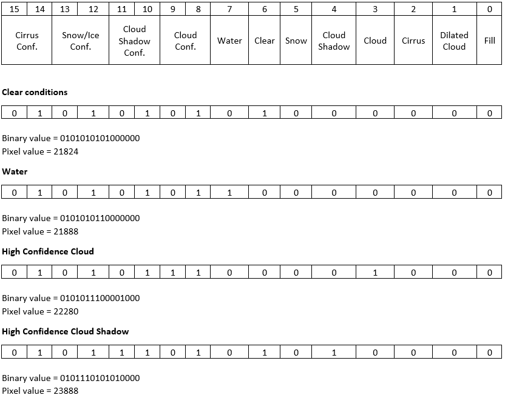

#### Historical fire perimeters

A polygon shapefile showing the perimeter of historical wildfires in BC (all wildfires before current year) is available on the [BC Data Catalogue](https://catalogue.data.gov.bc.ca/dataset/fire-perimeters-historical). This layer is available in `"data/PROT_HISTORICAL_FIRE_POLYS_SP/H_FIRE_PLY_polygon.shp"`. We describe a few fields below:

- `FIRE_NO`: A unique ID assigned to each layer (e.g. C30870 for the Prouton Lakes fire)
- `FIRE_YEAR`: The year when the fire happened
- `FIRE_CAUSE`: The cause of the fire (either `Lightning`, `Person` or `Unknown`)
- `SIZE_HA`: The area of each fire, in hectares (ha)

### Instructions

#### Step 1 - Historical fires in BC

**Provide code AND written answers for the following questions**. Use the `H_FIRE_PLY_polygon.shp` shapefile for this step.

**Include the following figure**

Use `ggplot2` to create a barplot (examples [here](http://www.sthda.com/english/wiki/ggplot2-barplots-quick-start-guide-r-software-and-data-visualization)) showing the total area burned per year in BC. Each bar should be colored by fire cause.

**Hints**

- Summarizing a `sf` objects is faster if the `geometry` information is *dropped*

#### Step 2 - Pre-processing Level-2 products and calculating vegetation indices

For each L2 product, put each surface reflectance band (Band 1 to Band 7) in the same raster object, **mask** pixels that do not have the value `21824` (*clear conditions*) in the `QA_PIXEL` layers and **crop** (no need to mask) the multi-layer raster to the Prouton Lakes fire extent. You also need to calculate the normalized vegetation difference index (NDVI) and the normalized burn ratio (NBR) for each cropped and masked raster (see hints). For each product, save the multi-layer SR product, NDVI and NBR layers in the `outputs` directory with the file name `ProductID_SR.tif`, `ProductID_NDVI.tif` or `ProductID_NBR.tif` (e.g. `LC08_L2SP_048023_20130701_20200912_02_T1_NBR.tif`)

**Include the following figure**

A true color composite image of the Prouton Lakes fire area before (**July 7 2015**) and after the fire (**July 15 2018**)

**Hints**

- The functions `list.files(..., pattern = ..., full.names = TRUE)` and `list.dirs(..., full.names = TRUE, recursive = FALSE)` can be used to list all the files and directories in a path.
- The function `basename(x)` can be used to keep only a file or directory name without the preceding path

```r
basename("path/to/dir/filename.tif")
```

```
## [1] "filename.tif"
```

```r
basename("path/to/dir")
```

```
## [1] "dir"
```

- The function `tools::file_path_sans_ext()` can be used to remove the extension (e.g. `.TIF`) from a file name

```r
tools::file_path_sans_ext("filename.tif")
```

```
## [1] "filename"
```

- The function `file.path()` can be used to construct a file path from characters.

```r
file.path("path", "to", "directory", "filename.tif")
```

```
## [1] "path/to/directory/filename.tif"
```

```r
file.path("path/to/directory", "filename.tif")
```

```
## [1] "path/to/directory/filename.tif"
```

- The function `paste0()` can be used to concatenate characters

```r
paste0("filename", ".tif")
```

```
## [1] "filename.tif"
```

- The function `terra::mask()` has an argument named `inverse`
- The function `terra::writeRaster(x, filename = fname, overwrite = TRUE)` is used to write a `SpatRaster` to a file on disk named `fname` (containing both the path and the file name with extension). The argument `overwrite = TRUE` allows `writeRaster` to overwrite an existing file with the same name.
- $$NDVI = \frac{NIR - RED}{NIR +
  RED}$$
- $$NBR = \frac{NIR - SWIR2}{NIR +
  SWIR2}$$

#### Step 3 - Yearly composites of NDVI and NBR

For each year in the NDVI and NBR time-series, create yearly composites by calculating the average value of each pixel from all the layers acquired in July and August. Make sure that `NA` values are not included in the average.

Then, calculate the average NDVI of all the pixels overlaid by the Prouton Lakes fire, for each year in the time series.

**Include the following figure**

Use `ggplot2` to create a connected scatterplot (points joined by lines) showing the average NDVI across the Prouton Lakes fire area through time.

**Hint**

`geom_line()` requires the `group` aesthetic to be set : `aes(x = ..., y = ..., group = ...)`. If there is no variable to group the lines by (i.e. a single group of data connected by lines), you can use `group = 1` (`aes(x = ..., y = ..., group = 1)`)

#### Step 4 - Classify burn severity

The burn severity of a fire can be estimated with the delta NBR (dNBR), which is the difference between pre-fire and post-fire NBR. Generally speaking, the higher dNBR is, the more severe the fire burned the land.

$$dNBR = NBR_{prefire} -
NBR_{postfire}$$
Field-based surveys are generally necessary to assess the burn severity of a fire. *Supervised classification* can then be used to create maps of burn severity. In our case, we will classify burn severity of the Prouton Lakes fire using dNBR thresholds. The reclassification table is described below:

| dNBR range | Burn Severity |
| --- | --- |
| -0.2 to 0.15 | unburned |
| 0.15 to 0.25 | low severity |
| 0.25 to 0.3 | medium severity |
| 0.3 to 1 | high severity |

Considering `2015` as the pre-fire year and `2018` as the post-fire year, create a raster of the Prouton Lakes fire burn severity. Make sure that the value of each pixel is the burn severity class (i.e. `"unburned"`, `"low severity"`, `"medium severity"`, `"high severity"`) instead of an arbitrary number (see hint).

**Include the following figure**

A plot of the dNBR raster classified into burn severity classes, overlaid with the boundary of the Prouton Lakes fire. The legend should show the burn severity levels (i.e. `"unburned"`, `"low severity"`, `"medium severity"`, `"high severity"`)

**Hints**

When a `SpatRaster` `x` has discrete values that represent classes (e.g. binary values representing water or land), you can set the `levels` of `x` as follows:

```r
levels(x) <- data.frame(id = c(0, 1),
                        label = c("water",
                                  "land"))
```

That way, values are transformed to a `factor`.

#### Step 5 - Post-fire vegetation recovery

Convert the burn severity raster to polygons (one polygon per burn severity class) and extract the NDVI values in 2018, 2019, 2020 and 2021 for each burn severity class. **Do not summarize the pixel values (e.g. mean). We want the value of every pixel in each burn severity class because we want to examine the distribution of NDVI values per burn severity class.**

**Hints**

- The function `terra::as.polygons` can be used to convert a `SpatRaster` to a polygon `SpatVector`. With the default argument `dissolve = TRUE`, the cells of the `SpatRaster` with the same values will be combined to a `SpatVector`

**Include the following figures**

- A plot showing the yearly NDVI composites in 2018, 2019, 2020 and 2021. Make sure that the legends of the 4 plots display the same range of values between 0 and 0.5 (`plot(..., range = c(0, 0.5))`)
- Use `ggplot2` to create a boxplot (examples [here](http://www.sthda.com/english/wiki/ggplot2-box-plot-quick-start-guide-r-software-and-data-visualization#change-box-plot-colors-by-groups)) showing the distribution of NDVI values per burn severity classes in 2018, 2019, 2020 and 2021. You can either make facets for each year (`facet_wrap()`) or make one plot with different colors for each boxplot. Make sure that the burn severity classes on the x axis area ordered from unburned to high severity (**hint: make sure that burn severity is an ordered factor**)

### Attaching packages

You can attach the package that you are using in the following code block

```r
#Attach packages here
```

### Type your code and answers here

#### Step 1 - Historical fires in BC

##### Code answer

```r
library(sf)
library(dplyr)
```

[figure not shown]

```r
library(ggplot2)
#reading in the shapefile and then changing the area_sqm to hectares
fires <- st_read("C:/Users/pritty01.stu/Documents/GEM520- LAB/Lab8-Main Demonstration/lab8_final/lab8_finalDemonstrationOfRSkills-assign/data/PROT_HISTORICAL_FIRE_POLYS_SP/H_FIRE_PLY_polygon.shp")
   #mutate(fires$AREA_SQM <- as.numeric(st_area(fires)) / 10000)

#Filtering the fires to only 2017
fires_2017 <- fires %>% filter(FIRE_YEAR == 2017)

#Question1
fires_2017_summary <- fires_2017 %>%
  st_drop_geometry() %>%
  summarise(total_land_burned = sum(AREA_SQM, na.rm = TRUE), count= n())

#Question2
largest_fires_2017 <- fires_2017 %>%
  st_drop_geometry() %>%
  arrange(desc(AREA_SQM)) %>%
  slice(1:3)%>%
  select(FIRE_NO,FIRE_CAUSE,AREA_SQM)

#Question3
prouton_lakes <- fires_2017 %>%
  st_drop_geometry() %>%
  filter(FIRE_NO == "C30870") %>%
  select(FIRE_NO, AREA_SQM)

#ggplot for a bar plot to show total area burned per year in BC
ggplot(fires, aes(x = FIRE_YEAR, y = AREA_SQM, fill = FIRE_CAUSE)) +
  geom_col() +
  labs(
    title = "Total Area Burned per Year in BC",
    x = "Year",
    y = "Area Burned (ha)",
    fill = "Fire Cause"
  )
```

#### Step 2 - Pre-processing Level-2 products and calculating vegetation indices

##### Code answer

```r
library(terra)
```

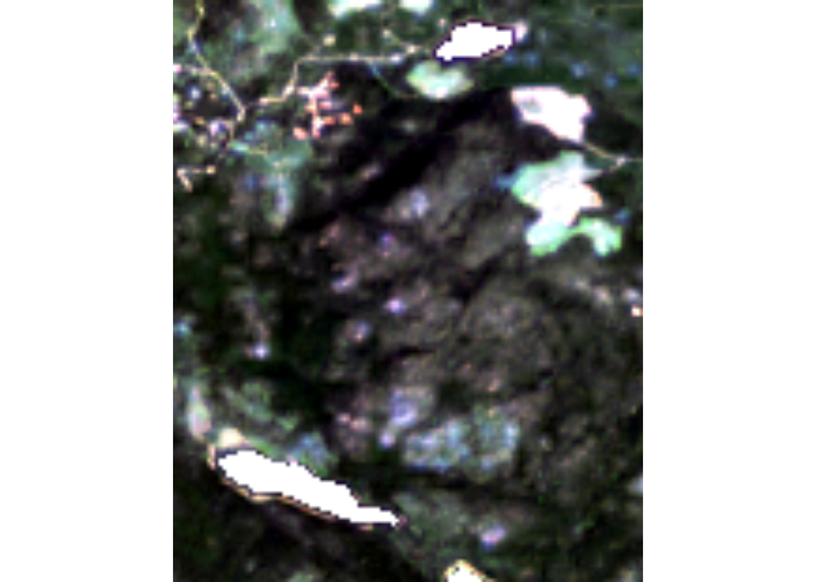

```r
library(dplyr)
library(tools)
library(sf)

# Directories
input_dir <- "C:/Users/pritty01.stu/Documents/GEM520- LAB/Lab8-Main Demonstration/lab8_final/lab8_finalDemonstrationOfRSkills-assign/data/Landsat 8 OLI_TIRS C2 L2"
output_dir_sr <- "C:/Users/pritty01.stu/Documents/GEM520- LAB/Lab8-Main Demonstration/lab8_final/lab8_finalDemonstrationOfRSkills-assign/output/LC08_L2SP_048023_SR"
output_dir_ndvi <- "C:/Users/pritty01.stu/Documents/GEM520- LAB/Lab8-Main Demonstration/lab8_final/lab8_finalDemonstrationOfRSkills-assign/output/LC08_L2SP_048023_NDVI"
output_dir_nbr <- "C:/Users/pritty01.stu/Documents/GEM520- LAB/Lab8-Main Demonstration/lab8_final/lab8_finalDemonstrationOfRSkills-assign/output/LC08_L2SP_048023_NBR"

# List product folders
flist <- list.dirs(input_dir, full.names = TRUE, recursive = FALSE)

# Read fire polygons
fires <- st_read("C:/Users/pritty01.stu/Documents/GEM520- LAB/Lab8-Main Demonstration/lab8_final/lab8_finalDemonstrationOfRSkills-assign/data/PROT_HISTORICAL_FIRE_POLYS_SP/H_FIRE_PLY_polygon.shp")
# Select Prouton Lakes (C30870)
prouton_lake <- fires %>% filter(FIRE_NO == "C30870")
prouton_lake_vect <- sf::st_transform(prouton_lake, crs = 32610)

sr_list <- list()
ndvi_list <- list()
nbr_list <- list()

for (m in 1:length(flist)) {

  flist_path <- flist[m]
  flist_name <- basename(flist_path)

  # SR bands
  band_files <- list.files(
    flist_path,
    pattern = "SR_B[1-7].TIF$",
    full.names = TRUE
  )


  # QA_PIXEL
  qa_file <- list.files(
    flist_path,
    pattern = "QA_PIXEL.TIF$",
    full.names = TRUE
  )

  # Read rasters
  bands <- rast(band_files)
  names(bands) <- paste0("B", 1:7)

  qa <- rast(qa_file)

  # Mask clear pixels (QA = 21824)
  clear_mask <- qa == 21824
  sr_mask <- mask(bands, clear_mask, maskvalues = FALSE)

  # Crop to Prouton Lakes fire
  sr_crop <- crop(sr_mask, prouton_lake_vect)

  # NDVI and NBR
  NDVI <- (sr_crop$B5 - sr_crop$B4) / (sr_crop$B5 + sr_crop$B4)
  names(NDVI) <- "NDVI"

  NBR <- (sr_crop$B5 - sr_crop$B7) / (sr_crop$B5 + sr_crop$B7)
  names(NBR) <- "NBR"

  # storing the files to output
  sr <- file.path(output_dir_sr, paste0(flist_name, "_SR.tif"))
  ndvi <- file.path(output_dir_ndvi, paste0(flist_name, "_NDVI.tif"))
  nbr <- file.path(output_dir_nbr, paste0(flist_name, "_NBR.tif"))

  #saving them to the disk
  writeRaster(sr_crop, sr, overwrite= TRUE)
  writeRaster(NDVI, ndvi, overwrite= TRUE)
  writeRaster(NBR, nbr, overwrite= TRUE)
}


#plotting the two images
before_fire <- rast("C:/Users/pritty01.stu/Documents/GEM520- LAB/Lab8-Main Demonstration/lab8_final/lab8_finalDemonstrationOfRSkills-assign/output/LC08_L2SP_048023_SR/LC08_L2SP_048023_20150707_20200909_02_T1_SR.tif")
after_fire <- rast("C:/Users/pritty01.stu/Documents/GEM520- LAB/Lab8-Main Demonstration/lab8_final/lab8_finalDemonstrationOfRSkills-assign/output/LC08_L2SP_048023_SR/LC08_L2SP_048023_20180715_20200831_02_T1_SR.tif")

plotRGB(before_fire, r = "B4", g = "B3", b = "B2", stretch = "lin")
```

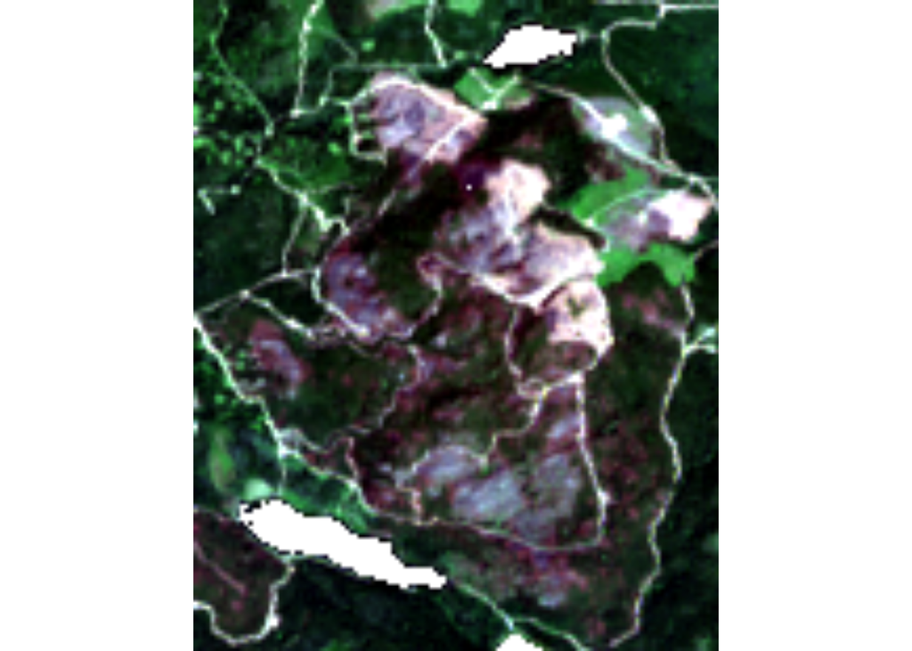

```r
plotRGB(after_fire,  r = "B4", g = "B3", b = "B2", stretch = "lin")
```

#### Step 3 - Yearly composites of NDVI and NBR

##### Code answer

```r
library(terra)
library(sf)
library(dplyr)
library(stringr)
library(lubridate)
library(tidyr)
```

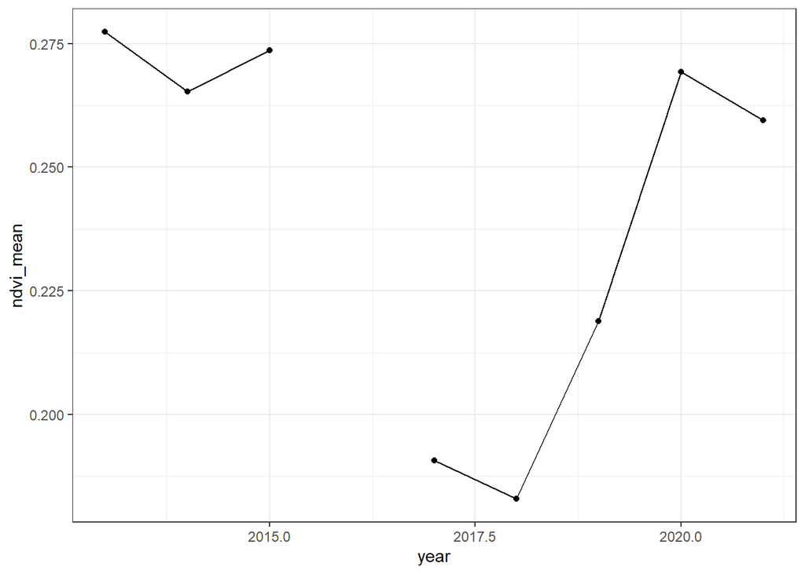

```r
library(ggplot2)


nbr_flist <- list.files(
  "C:/Users/pritty01.stu/Documents/GEM520- LAB/Lab8-Main Demonstration/lab8_final/lab8_finalDemonstrationOfRSkills-assign/output/LC08_L2SP_048023_NBR",
  pattern = "tif$", full.names = TRUE
)

ndvi_flist <- list.files(
  "C:/Users/pritty01.stu/Documents/GEM520- LAB/Lab8-Main Demonstration/lab8_final/lab8_finalDemonstrationOfRSkills-assign/output/LC08_L2SP_048023_NDVI",
  pattern = "tif$", full.names = TRUE
)

ndvi_ts <- rast(ndvi_flist)
nbr_ts  <- rast(nbr_flist)


date_str <- str_extract(basename(ndvi_flist), "\\d{8}")
date_ts  <- ymd(date_str)

years  <- year(date_ts)
months <- month(date_ts)

unique_years <- sort(unique(years))

prouton_lake <- fires %>% filter(FIRE_NO == "C30870")
prouton_lake_vect <- vect(prouton_lake)   # convert to SpatVector
prouton_lake_vect <- project(prouton_lake_vect, ndvi_ts)

ndvi_yearly_list <- list()
nbr_yearly_list  <- list()

#loop through each year
for (i in 1:length(unique_years)) {

    yr <- unique_years[i]

    #Filter for July or August of this year
    trg_layers <- which(year(date_ts) == yr & month(date_ts) %in% c(7,8))

    # Subset rasters
    ndvi_subset <- subset(ndvi_ts, trg_layers)
    nbr_subset  <- subset(nbr_ts,  trg_layers)

    # Compute yearly composite (mean)
    ndvi_avg <- app(ndvi_subset, fun = mean, na.rm = TRUE)
    nbr_avg  <- app(nbr_subset,  fun = mean, na.rm = TRUE)

    # Name layers with the year
    names(ndvi_avg) <- as.character(yr)
    names(nbr_avg)  <- as.character(yr)

    # Store
    ndvi_yearly_list[[i]] <- ndvi_avg
    nbr_yearly_list[[i]]  <- nbr_avg
}


ndvi_yearly <- rast(ndvi_yearly_list)
nbr_yearly  <- rast(nbr_yearly_list)

ndvi_mean <- terra::extract(ndvi_yearly, prouton_lake_vect, fun = mean, na.rm = TRUE)

ndvi_long <- ndvi_mean %>%
  select(-ID) %>%
  pivot_longer(
    cols = everything(),
    names_to = "year",
    values_to = "ndvi"
  ) %>%
  mutate(year = as.numeric(year))

ndvi_roi_summary <- ndvi_long %>%
  group_by(year) %>%
  summarise(ndvi_mean = mean(ndvi, na.rm = TRUE)) %>%
  arrange(desc(ndvi_mean))

ggplot(ndvi_roi_summary, aes(x = year, y = ndvi_mean, group = 1)) +
geom_point() +
geom_line() +
theme_bw()
```

#### Step 4 - Classify burn severity

##### Code answer

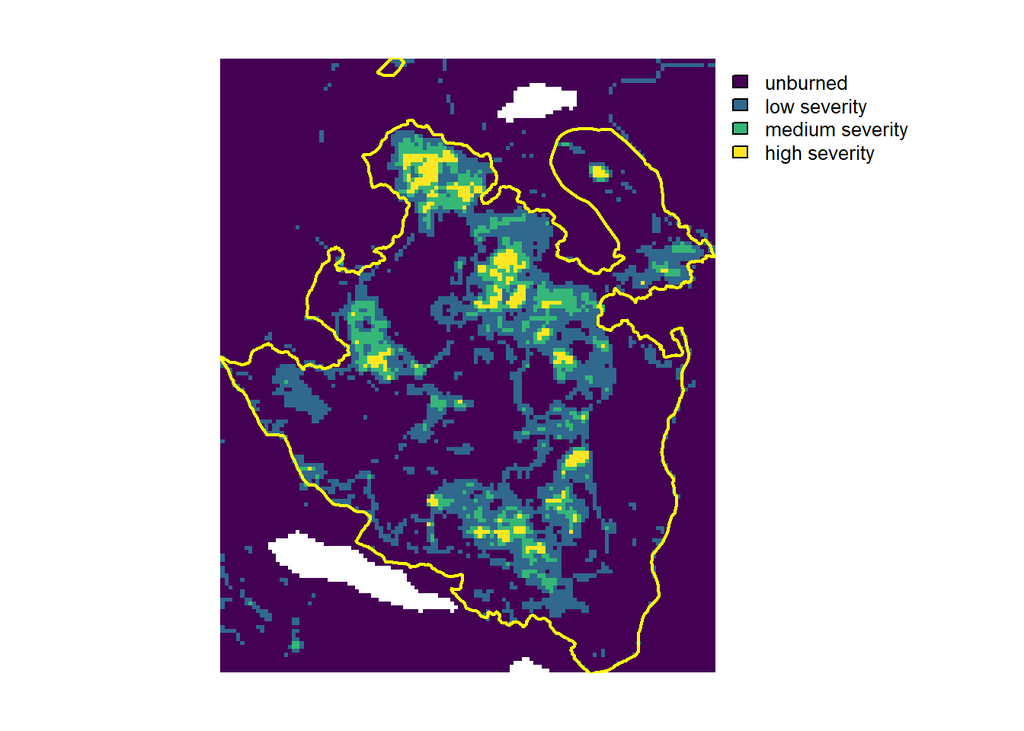

```r
#getting the rasters that are pre and post
pre_fire <- nbr_yearly$`2015`
post_fire <- nbr_yearly$`2018`

#cropping to prouton lake extends
pre_fire_crop <- crop(pre_fire, prouton_lake_vect)
post_fire_crop <- crop(post_fire, prouton_lake_vect)

#calculating the dNBR
dNBR <- pre_fire_crop - post_fire_crop

#reclassify
reclassify <- matrix(c(
  -0.2, 0.15, 1,
  0.15, 0.25, 2,
  0.25, 0.3, 3,
  0.3, 1, 4),byrow = TRUE, ncol = 3)

burn <- classify(dNBR, reclassify)

#givng claases
levels(burn) <- data.frame(id = c(1,2,3,4),
label = c("unburned","low severity","medium severity","high severity"))

#plotting the map
plot(burn, axes = FALSE, legend = TRUE)
#overlaying the boundary
plot(prouton_lake_vect, add = TRUE, border = "yellow", lwd = 2)
```

#### Step 5 - Post-fire vegetation recovery

##### Code answer

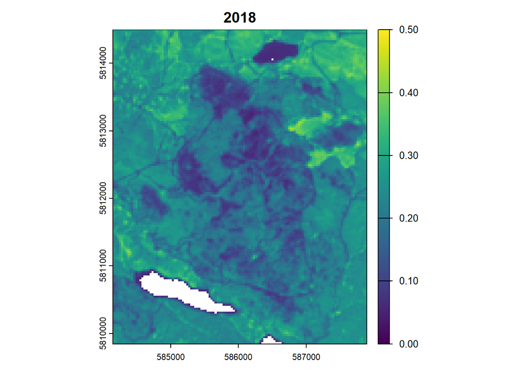

```r
#converting burn severity nbr to polygons
burn_poly <- terra::as.polygons(burn, dissolve = TRUE)

#extracting them individually in regards to the burn severity
ndvi_2018 <- terra::extract(ndvi_yearly[["2018"]], burn_poly)
ndvi_2019 <- terra::extract(ndvi_yearly[["2019"]], burn_poly)
ndvi_2020 <- terra::extract(ndvi_yearly[["2020"]], burn_poly)
ndvi_2021 <- terra::extract(ndvi_yearly[["2021"]], burn_poly)


#long format to add the column burn severity ~ 2018
ndvi_long_2018 <- ndvi_2018 %>%
  pivot_longer(cols = -ID, values_to = "ndvi") %>%
  mutate(
    burn_severity = factor(ID,
                           levels = c(1,2,3,4),
                           labels = c("unburned",
                                      "low severity",
                                      "medium severity",
                                      "high severity")
  ))


#plot them separately for each year
plot(ndvi_yearly[["2018"]], main = "2018", range = c(0,0.5))
```

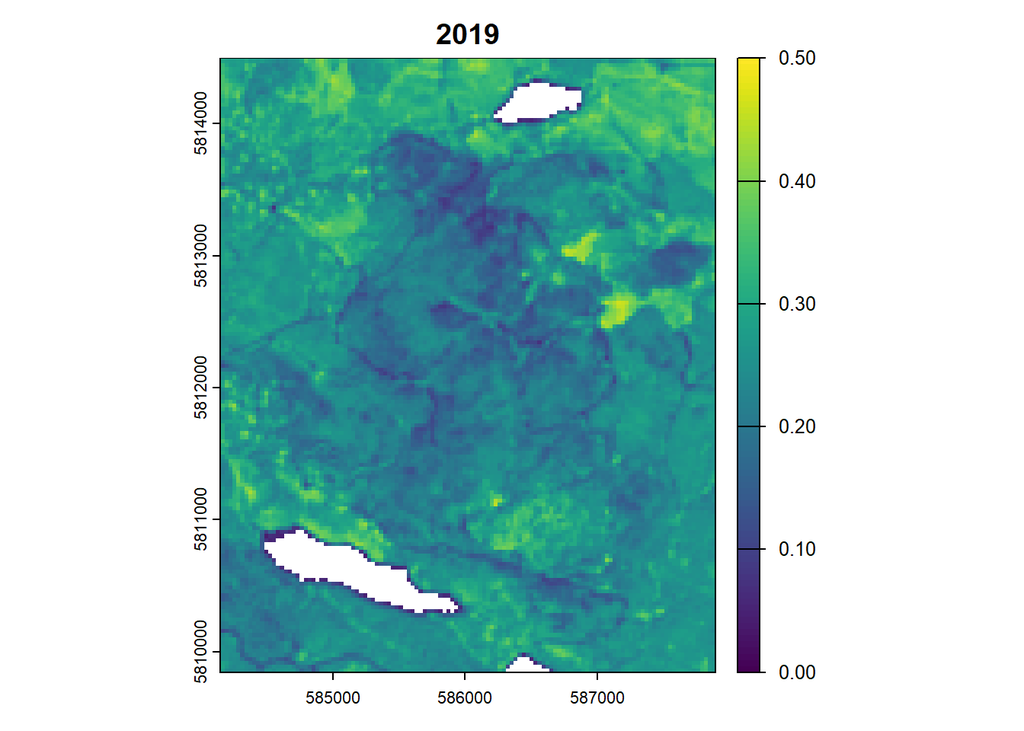

```r
#long format to add the column burn severity ~ 2019
ndvi_long_2019 <- ndvi_2019 %>%
  pivot_longer(cols = -ID, values_to = "ndvi") %>%
  mutate(
    burn_severity = factor(ID,
                           levels = c(1,2,3,4),
                           labels = c("unburned",
                                      "low severity",
                                      "medium severity",
                                      "high severity")
  ))


#plot them separately for each year
plot(ndvi_yearly[["2019"]], main = "2019", range = c(0,0.5))
```

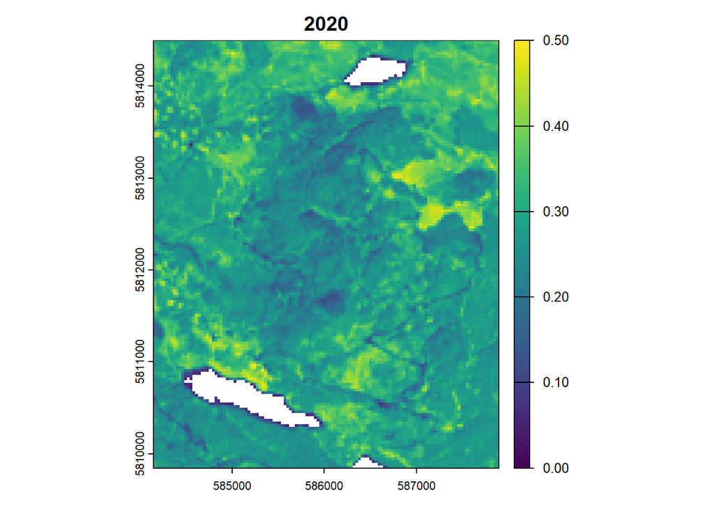

```r
#long format to add the column burn severity ~ 2020
ndvi_long_2020 <- ndvi_2020 %>%
  pivot_longer(cols = -ID, values_to = "ndvi") %>%
  mutate(
    burn_severity = factor(ID,
                           levels = c(1,2,3,4),
                           labels = c("unburned",
                                      "low severity",
                                      "medium severity",
                                      "high severity")
  ))

#plot them separately for each year
plot(ndvi_yearly[["2020"]], main = "2020", range = c(0,0.5))
```

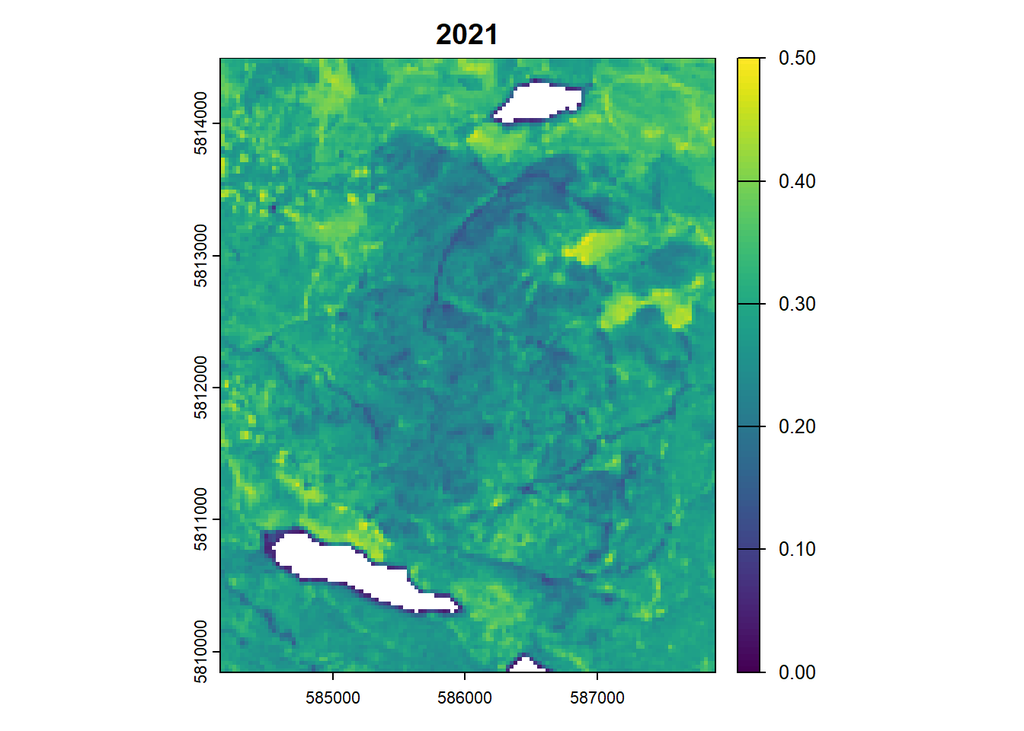

```r
#long format to add the column burn severity ~ 2021
ndvi_long_2021 <- ndvi_2021 %>%
  pivot_longer(cols = -ID, values_to = "ndvi") %>%
  mutate(
    burn_severity = factor(ID,
                           levels = c(1,2,3,4),
                           labels = c("unburned",
                                      "low severity",
                                      "medium severity",
                                      "high severity")
  ))

#plot them separately for each year
plot(ndvi_yearly[["2021"]], main = "2021", range = c(0,0.5))
```

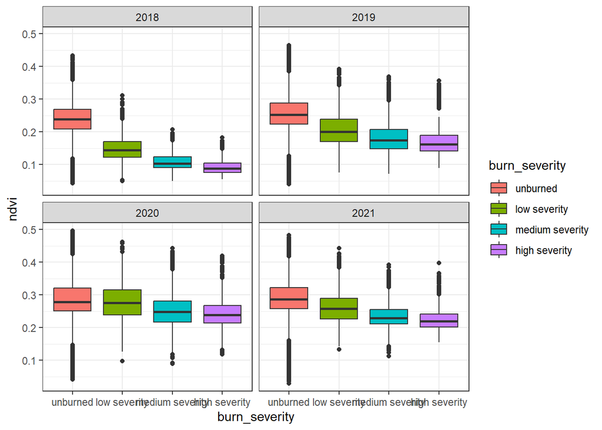

```r
ndvi_long_2018$year <- "2018"
ndvi_long_2019$year <- "2019"
ndvi_long_2020$year <- "2020"
ndvi_long_2021$year <- "2021"

ndvi_all <- rbind(ndvi_long_2018,
                  ndvi_long_2019,
                  ndvi_long_2020,
                  ndvi_long_2021)

ggplot(ndvi_all, aes(x = burn_severity, y = ndvi, fill = burn_severity)) +
  geom_boxplot() +
  facet_wrap(~year, ncol = 2) +
  theme_bw()
```